# EDA_Modeling

## Modeling with caret Package

Makes it easy to test many different models with very few changes. The first 25 packages in caret are:

```r
head(names(getModelInfo()), 25)
```

```
##  [1] "ada"            "AdaBag"         "AdaBoost.M1"    "adaboost"
##  [5] "amdai"          "ANFIS"          "avNNet"         "awnb"
##  [9] "awtan"          "bag"            "bagEarth"       "bagEarthGCV"
## [13] "bagFDA"         "bagFDAGCV"      "bam"            "bartMachine"
## [17] "bayesglm"       "binda"          "blackboost"     "blasso"
## [21] "blassoAveraged" "bridge"         "brnn"           "BstLm"
## [25] "bstSm"
```

Will use more data from UCI. This time diabetes data. https:/archive.ics.uci.edu/ml/machine-learning-databases/00296/dataset_diabetes.zip

> UIC changed file types. Diabetes is now a tar.Z file. Used 7-Zip to extract and copy files to the EDA data diabetes folder

```r
# UCI Diabetes 130-US hospitals for years 1999-2008 Data Set
# https://archive.ics.uci.edu/ml/machine-learning-databases/00296/
binData <- getBinaryURL("https://archive.ics.uci.edu/ml/machine-learning-databases/00296/dataset_diabetes.zip",
                        ssl.verifypeer=FALSE)

#conObj <- file("dataset_diabetes.zip", open = "wb")source("../EDA/EDA_PipelineFunctions.R")
conObj <- file("../EDA/data/dataset_diabetes.zip", open = "wb")
writeBin(binData, conObj)

# don't forget to close it
close(conObj)

# open diabetes file
files <- unzip("../EDA/data/dataset_diabetes.zip")
readLines(files[1], n=5)
```

```
## [1] "encounter_id,patient_nbr,race,gender,age,weight,admission_type_id,discharge_disposition_id,admission_source_id,time_in_hospital,payer_code,medical_specialty,num_lab_procedures,num_procedures,num_medications,number_outpatient,number_emergency,number_inpatient,diag_1,diag_2,diag_3,number_diagn…
## [2] "2278392,8222157,Caucasian,Female,[0-10),?,6,25,1,1,?,Pediatrics-Endocrinology,41,0,1,0,0,0,250.83,?,?,1,None,None,No,No,No,No,No,No,No,No,No,No,No,No,No,No,No,No,No,No,No,No,No,No,No,No,No,NO"
## [3] "149190,55629189,Caucasian,Female,[10-20),?,1,1,7,3,?,?,59,0,18,0,0,0,276,250.01,255,9,None,None,No,No,No,No,No,No,No,No,No,No,No,No,No,No,No,No,No,Up,No,No,No,No,No,Ch,Yes,>30"
## [4] "64410,86047875,AfricanAmerican,Female,[20-30),?,1,1,7,2,?,?,11,5,13,2,0,1,648,250,V27,6,None,None,No,No,No,No,No,No,Steady,No,No,No,No,No,No,No,No,No,No,No,No,No,No,No,No,No,Yes,NO"
## [5] "500364,82442376,Caucasian,Male,[30-40),?,1,1,7,2,?,?,44,1,16,0,0,0,8,250.43,403,7,None,None,No,No,No,No,No,No,No,No,No,No,No,No,No,No,No,No,No,Up,No,No,No,No,No,Ch,Yes,NO"
```

First line is just headers - there are a lot of them.

Note there are some `?` in the data instead of `NAs`.

```r
diabetes <- data.frame(read_csv(files[1], na = "?"))#another good reason to use readr!
dim(diabetes)
```

```
## [1] 101766     50
```

Clean the data further and drop a few too:

```r
#drop useless variables
diabetes <- diabetes %>% select(-encounter_id, -patient_nbr, -examide, -citoglipton)

#fix outcome variable
diabetes$readmitted <- ifelse(diabetes$readmitted =="<30", "yes", "no")
```

Before creating dummy variables, lets see how many unique feature counts in the character-based features:

```r
charcolumns <- names(diabetes[sapply(diabetes, is.character)])
non_numeric_data_dim <- c()
for(colname in charcolumns){
     non_numeric_data_dim <- rbind(non_numeric_data_dim, c(colname, length(unique(diabetes[, colname]))))
}
class(non_numeric_data_dim)
```

```
## [1] "matrix"
```

```r
non_numeric_data_dim <- data.frame(non_numeric_data_dim) %>%
     mutate(feature_name = as.character(X1), unique_counts = as.numeric(as.character(X2))) %>%
     select(feature_name, unique_counts) %>% arrange(desc(unique_counts))

head(non_numeric_data_dim)
```

```
##        feature_name unique_counts
## 1            diag_3           790
## 2            diag_2           749
## 3            diag_1           717
## 4 medical_specialty            73
## 5        payer_code            18
## 6               age            10
```

If we bianrise all of these, we end up with over 2256 new features! Therefore, use `Binarize_Features` function to take the top 20 features from each diag_X and discard the rest. Repeat with medical_specialty. (Go to the R Script file that has this function. The file is named `EDA_PipelineFunctions.R`)

```r
diabetes <- Binarize_Features(data_set = diabetes, leave_out_one_level = TRUE, max_level_count = 20,
                    features_to_ignore = "readmitted")
glimpse(diabetes)
```

```
## Observations: 101,766
## Variables: 190
## $ admission_type_id                                   <int> 6, 1, 1, 1...
## $ discharge_disposition_id                            <int> 25, 1, 1, ...
## $ admission_source_id                                 <int> 1, 7, 7, 7...
## $ time_in_hospital                                    <int> 1, 3, 2, 2...
## $ num_lab_procedures                                  <int> 41, 59, 11...
## $ num_procedures                                      <int> 0, 0, 5, 1...
## $ num_medications                                     <int> 1, 18, 13,...
## $ number_outpatient                                   <int> 0, 0, 2, 0...
## $ number_emergency                                    <int> 0, 0, 0, 0...
## $ number_inpatient                                    <int> 0, 0, 1, 0...
## $ number_diagnoses                                    <int> 1, 9, 6, 7...
## $ readmitted                                          <chr> "no", "no"...
## $ race_AfricanAmerican                                <dbl> 0, 0, 1, 0...
```

[output cut: 177 more lines]

Everything is a number except for the dependent variable - just as we need it!

Now run the `Feature_Engineer_Integers` function and use `nearZeroVar` to remove monotomic features:

```r
diabetes <- Feature_Engineer_Integers(data_set=diabetes, features_to_ignore=c("admission_type_id", "discharge_disposition_id", "admission_source_id"))

nzv = nearZeroVar(diabetes, saveMetrics=TRUE)
length(rownames(nzv[nzv$nzv==FALSE, ]))
```

```
## [1] 66
```

```r
diabetes <- diabetes[,rownames(nzv[nzv$nzv==FALSE, ])]
dim(diabetes)
```

```
## [1] 101766     66
```

### GBM

```r
outcome_name <- "readmitted"

predictor_names <- setdiff(names(diabetes), outcome_name)

splitIndex <- createDataPartition(diabetes[, outcome_name], p = .75, list = FALSE, times = 1)
train_data <- diabetes[splitIndex, ]
test_data <- diabetes[-splitIndex, ]
```

```r
objControl <- trainControl(method="cv", number = 2, returnResamp = "none",
                 summaryFunction = twoClassSummary, classProbs = TRUE)
```

This is a classification model so we are requesting our mterics use ROC instead of RMSE:

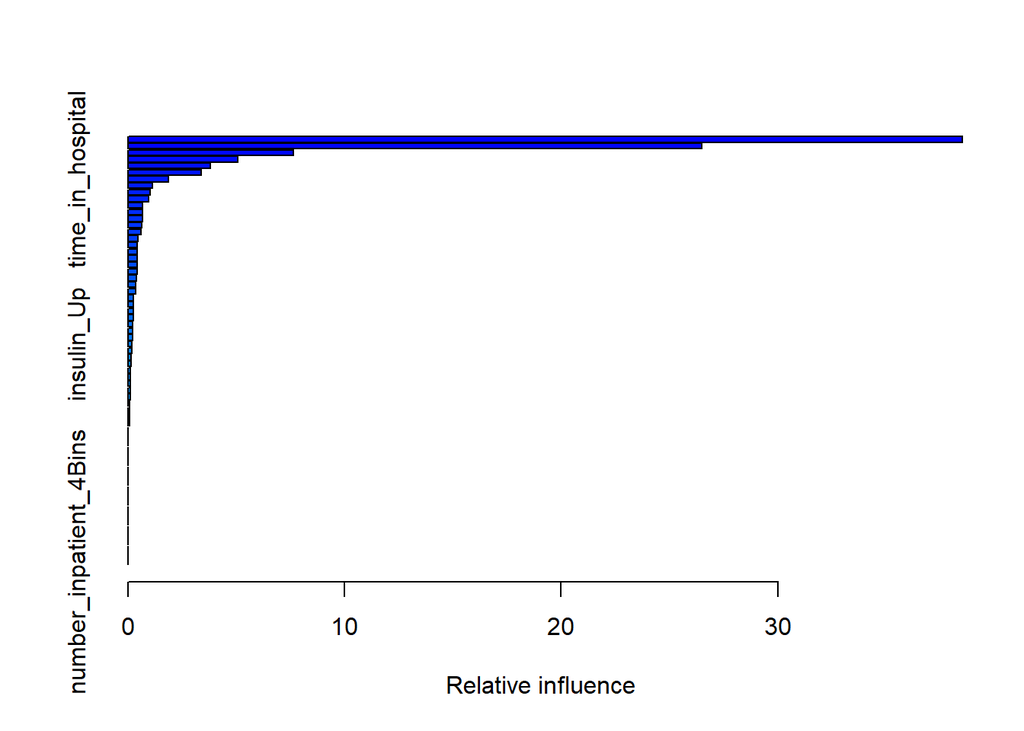

```
##                                                                               var
## number_inpatient                                                 number_inpatient
## discharge_disposition_id                                 discharge_disposition_id
## number_inpatient_IsZero                                   number_inpatient_IsZero
## number_emergency                                                 number_emergency
## num_medications                                                   num_medications
## num_lab_procedures                                             num_lab_procedures
## time_in_hospital                                                 time_in_hospital
## diabetesMed_Yes                                                   diabetesMed_Yes
## num_procedures                                                     num_procedures
## number_diagnoses                                                 number_diagnoses
## insulin_Down                                                         insulin_Down
## diag_2_250                                                             diag_2_250
## age_.50.60.                                                           age_.50.60.
## number_diagnoses_2Bins                                     number_diagnoses_2Bins
## diag_1_428                                                             diag_1_428
## payer_code_MC                                                       payer_code_MC
## medical_specialty_Cardiology                         medical_specialty_Cardiology
## number_outpatient                                               number_outpatient
## medical_specialty_NA                                         medical_specialty_NA
## diag_3_Other                                                         diag_3_Other
## number_diagnoses_4Bins                                     number_diagnoses_4Bins
## diag_3_250                                                             diag_3_250
## admission_type_id                                               admission_type_id
## age_.70.80.                                                           age_.70.80.
## metformin_Steady                                                 metformin_Steady
## age_.80.90.                                                           age_.80.90.
## diag_3_401                                                             diag_3_401
## payer_code_HM                                                       payer_code_HM
## diag_2_276                                                             diag_2_276
## time_in_hospital_2Bins                                     time_in_hospital_2Bins
## medical_specialty_Emergency.Trauma             medical_specialty_Emergency.Trauma
## insulin_Up                                                             insulin_Up
## A1Cresult_.8                                                         A1Cresult_.8
## number_emergency_IsZero                                   number_emergency_IsZero
## diag_3_276                                                             diag_3_276
## medical_specialty_InternalMedicine             medical_specialty_InternalMedicine
## race_AfricanAmerican                                         race_AfricanAmerican
## age_.40.50.                                                           age_.40.50.
## rosiglitazone_Steady                                         rosiglitazone_Steady
```

[output cut: 77 more lines]

```
## insulin_Steady                            0.00000000
## change_Ch                                 0.00000000
## num_lab_procedures_2Bins                  0.00000000
## num_lab_procedures_4Bins                  0.00000000
## num_procedures_IsZero                     0.00000000
## num_procedures_2Bins                      0.00000000
## num_procedures_4Bins                      0.00000000
## num_medications_2Bins                     0.00000000
## num_medications_4Bins                     0.00000000
## number_outpatient_2Bins                   0.00000000
## number_outpatient_4Bins                   0.00000000
## number_emergency_2Bins                    0.00000000
## number_emergency_4Bins                    0.00000000
## number_inpatient_2Bins                    0.00000000
## number_inpatient_4Bins                    0.00000000
```

```r
gbm_caret_model <- train(train_data[, predictor_names], as.factor(train_data[, outcome_name]),
                    method="gbm", trControl = objControl, metric = "ROC", preProcess = c("center", "scale"))
summary(gbm_caret_model)
```

`Caret` also reports what tuning parameters were most important to the model:

```r
gbm_caret_model
```

```
## Stochastic Gradient Boosting
##
## 76325 samples
##    65 predictor
##     2 classes: 'no', 'yes'
##
## Pre-processing: centered (65), scaled (65)
## Resampling: Cross-Validated (2 fold)
## Summary of sample sizes: 38162, 38163
## Resampling results across tuning parameters:
##
##   interaction.depth  n.trees  ROC        Sens       Spec
##   1                   50      0.6501715  0.9997345  0.001173985
##   1                  100      0.6558109  0.9992479  0.004813336
##   1                  150      0.6589871  0.9990414  0.005635126
##   2                   50      0.6568357  0.9994691  0.004343743
##   2                  100      0.6648800  0.9992479  0.007278704
##   2                  150      0.6676401  0.9991004  0.010213665
##   3                   50      0.6619487  0.9994248  0.005752524
##   3                  100      0.6672258  0.9990119  0.009039681
##   3                  150      0.6698570  0.9986874  0.010918056
##
## Tuning parameter 'shrinkage' was held constant at a value of 0.1
##
## Tuning parameter 'n.minobsinnode' was held constant at a value of 10
## ROC was used to select the optimal model using  the largest value.
## The final values used for the model were n.trees = 150,
##  interaction.depth = 3, shrinkage = 0.1 and n.minobsinnode = 10.
```

Test using test_data. Two type of evalauation:

- raw - outputs class prediction - yes or no. Useful in mutinomial models when predicting more thna 2 values.
- prob - outputs probabilities (needed to control teh threshold and ability to use AUC Curve)

Call the predict functionpassing our trained model and testing data. We will look at class predictins and use the caret postResample function to get accuracy score.

```r
predictions <- predict(object = gbm_caret_model, test_data[, predictor_names], type = "raw")
head(predictions)
```

```
## [1] no no no no no no
## Levels: no yes
```

```r
postResample(pred = predictions, obs = as.factor(test_data[, outcome_name]))
```

```
##   Accuracy      Kappa
## 0.88817263 0.01354183
```

Wow, 88% accurate . Good, right. Not so fast. . . .

```r
prop.table(table(as.factor(diabetes[, outcome_name])))
```

```
##
##        no       yes
## 0.8884008 0.1115992
```

The model and the historical data are the same! Model assumed that patients are not readmitted. Predicting who is not going to be readmitted is easy! The data is signifiantly skewed. Therefore, the model is not a good measure how this model works. AUC handles skewed data well. Of course for AUC, we require probability output.

```r
predictions <- predict(object = gbm_caret_model, test_data[, predictor_names], type = "prob")
head(predictions)
```

```
##          no        yes
## 1 0.9178539 0.08214608
## 2 0.9342594 0.06574060
## 3 0.8743431 0.12565687
## 4 0.8620090 0.13799102
## 5 0.8796489 0.12035111
## 6 0.9421720 0.05782796
```

To get the AUC score, pass the `yes` column to the `roc` function (each row adds to 1 but we are interested in the `yes`, the **readmitted**.)

```r
auc <- roc(ifelse(test_data[, outcome_name] == "yes", 1, 0), predictions[[2]])
auc$auc
```

```
## Area under the curve: 0.6618
```

## K-Means Clustering

Let’s use our pipeline to prepare a data set for a k-means (https://stat.ethz.ch/R-manual/R-devel/library/stats/html/kmeans.html) unsupervised model. First we need to load into memory the following functions: Impute_Features and Get_Free_Text_Measures.

Now, load the Auto MPG Data Set (https://archive.ics.uci.edu/ml/datasets/Auto+MPG). This is a simple data set but requires the above function calls as it contains missing data, character-based variables, and numerical data. Let’s load it in memory and run our pipeline functions:

```r
AutoMpg_data <- read.csv("http://mlr.cs.umass.edu/ml/machine-learning-databases/auto-mpg/auto-mpg.data",
     na.strings = '?', header=FALSE, sep="", as.is=TRUE,
     col.names = c("mpg", "cylinders", "displacement", "horsepower", "weight", "acceleration", "model",
                   "origin", "car_name"),
     stringsAsFactors = FALSE)

AutoMpg_data <- Get_Free_Text_Measures(data_set = AutoMpg_data, minimum_unique_threshold=0.5)
AutoMpg_data <- Impute_Features(data_set = AutoMpg_data, use_mean_instead_of_0 = FALSE)
```

Take a quick look at the data:

```r
str(AutoMpg_data)
```

```
## 'data.frame':    398 obs. of  12 variables:
##  $ mpg                     : num  18 15 18 16 17 15 14 14 14 15 ...
##  $ cylinders               : num  8 8 8 8 8 8 8 8 8 8 ...
##  $ displacement            : num  307 350 318 304 302 429 454 440 455 390 ...
##  $ horsepower              : num  130 165 150 150 140 198 220 215 225 190 ...
##  $ weight                  : num  3504 3693 3436 3433 3449 ...
##  $ acceleration            : num  12 11.5 11 12 10.5 10 9 8.5 10 8.5 ...
##  $ model                   : num  70 70 70 70 70 70 70 70 70 70 ...
##  $ origin                  : num  1 1 1 1 1 1 1 1 1 1 ...
##  $ car_name_word_count     : num  3 3 2 3 2 3 2 3 2 3 ...
##  $ car_name_character_count: num  25 17 18 13 11 16 16 17 16 18 ...
##  $ car_name_1st_word       : chr  "chevrolet" "buick" "plymouth" "amc" ...
##  $ car_name_2nd_word       : chr  "chevelle" "skylark" "satellite" "rebel" ...
```

Use the k-means model to discover the relationship between acceleration and weight of vehicles using 3 clusters.

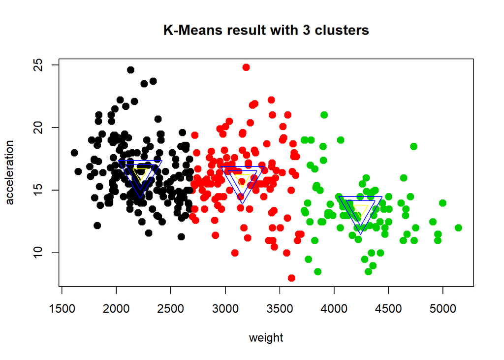

```r
km1 = kmeans(x = select(AutoMpg_data, weight, acceleration), centers = 3)

# Plot results
{plot(select(AutoMpg_data, weight, acceleration), col =km1$cluster, main="K-Means result with 3 clusters", pch=20, cex=2)

# find each cluster's centroids
points(km1$centers, pch=6, col='blue', cex=6)
points(km1$centers, pch=6, col='blue', cex=4)
points(km1$centers, pch=6, col='blue', cex=2)
points(km1$centers, pch=6, col='yellow', cex=2)}
```

K-means did split the data into three groups. Unfortunately, the use of k-means here is dimished due to the obvious linear relationship between both variables.

To make this clustering discovery more interesting, we’re going to transform our data set using the car_name_first_word variable which is none other than the brand of each car:

```r
unique(AutoMpg_data$car_name_1st_word)
```

```
##  [1] "chevrolet"     "buick"         "plymouth"      "amc"
##  [5] "ford"          "pontiac"       "dodge"         "toyota"
##  [9] "datsun"        "volkswagen"    "peugeot"       "audi"
## [13] "saab"          "bmw"           "chevy"         "hi"
## [17] "mercury"       "opel"          "fiat"          "oldsmobile"
## [21] "chrysler"      "mazda"         "volvo"         "renault"
## [25] "toyouta"       "maxda"         "honda"         "subaru"
## [29] "chevroelt"     "capri"         "vw"            "mercedes-benz"
## [33] "cadillac"      "mercedes"      "vokswagen"     "triumph"
## [37] "nissan"
```

Group the data by brand into a new data set called brand_set and average all the data by brand. We also use the brand name as a row name (this will become apparent later on):

```r
brand_set <- select(AutoMpg_data, weight, acceleration, car_name_1st_word) %>% group_by(car_name_1st_word) %>%
     summarize_each(funs(mean)) %>% data.frame
```

```
## `summarise_each()` is deprecated.
## Use `summarise_all()`, `summarise_at()` or `summarise_if()` instead.
## To map `funs` over all variables, use `summarise_all()`
```

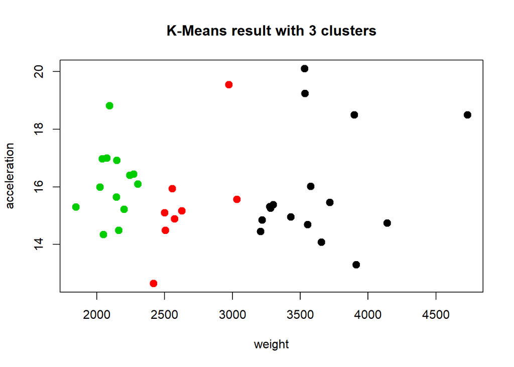

```r
row.names(brand_set) <- brand_set$car_name_1st_word
#Note:  factoextra requires rownames for it to plot properly
brand_set <- dplyr::select(brand_set, -car_name_1st_word)

km1 = kmeans(x = brand_set, centers = 3)
# Plot results
plot(brand_set, col =km1$cluster, main="K-Means result with 3 clusters", pch=20, cex=2)
```

Use the factoextra (https://cran.r-project.org/web/packages/factoextra/index.html) library. This is why we replaced the row names with the actual brand!

```r
km1 = kmeans(x = brand_set, centers = 3)
print(km1)
```

```
## K-means clustering with 3 clusters of sizes 14, 19, 4
##
## Cluster means:
##     weight acceleration
## 1 3377.402     16.06959
## 2 2250.898     15.68187
## 3 4170.250     16.26250
##
## Clustering vector:
##           amc          audi           bmw         buick      cadillac
##             1             2             2             1             3
##         capri     chevroelt     chevrolet         chevy      chrysler
##             2             3             1             1             3
##        datsun         dodge          fiat          ford            hi
##             2             1             2             1             3
##         honda         maxda         mazda      mercedes mercedes-benz
##             2             2             2             1             1
##       mercury        nissan    oldsmobile          opel       peugeot
##             1             2             1             2             1
##      plymouth       pontiac       renault          saab        subaru
##             1             1             2             2             2
##        toyota       toyouta       triumph     vokswagen    volkswagen
##             2             2             2             2             2
##         volvo            vw
##             1             2
##
## Within cluster sum of squares by cluster:
## [1] 676136.5 885185.0 457857.8
##  (between_SS / total_SS =  89.7 %)
##
## Available components:
##
## [1] "cluster"      "centers"      "totss"        "withinss"
## [5] "tot.withinss" "betweenss"    "size"         "iter"
## [9] "ifault"
```

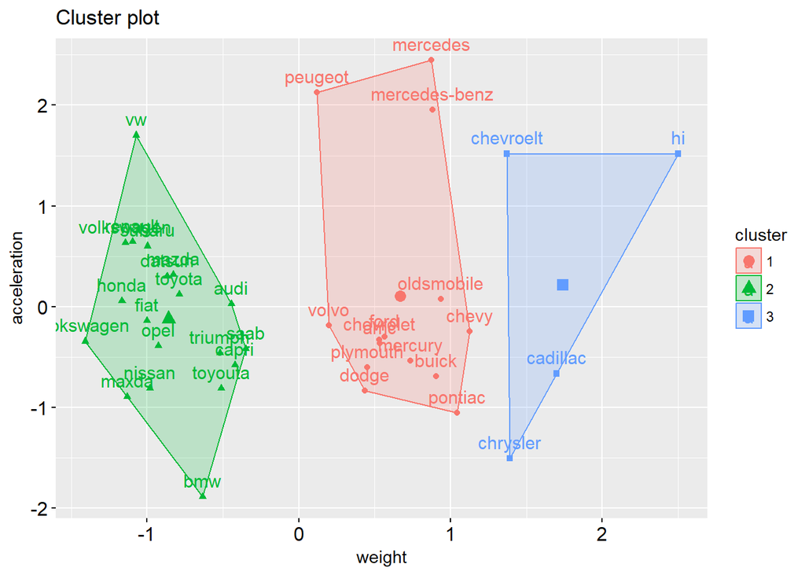

```r
fviz_cluster(km1, data = brand_set)
```

Another great tool in factoextra is the ability to advise on how many clusters to use.

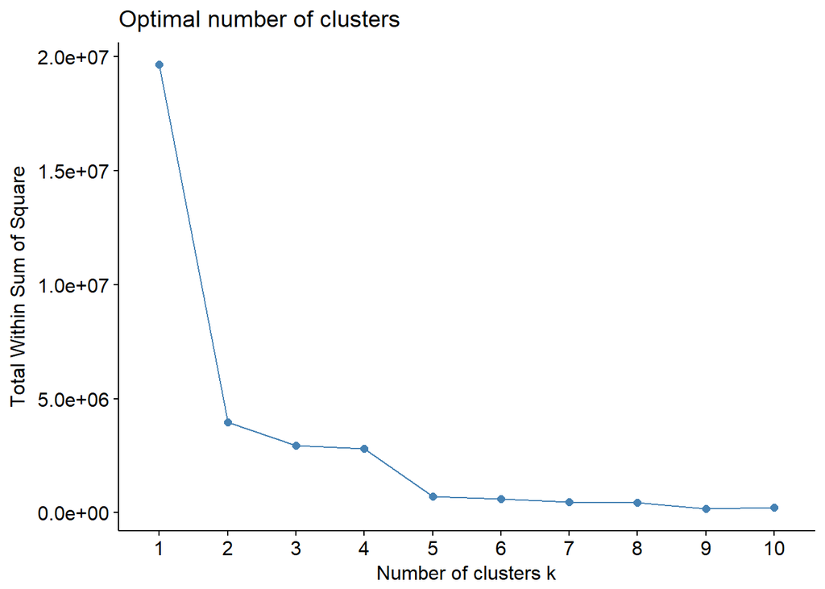

```r
fviz_nbclust(brand_set, kmeans, method = "wss")
```

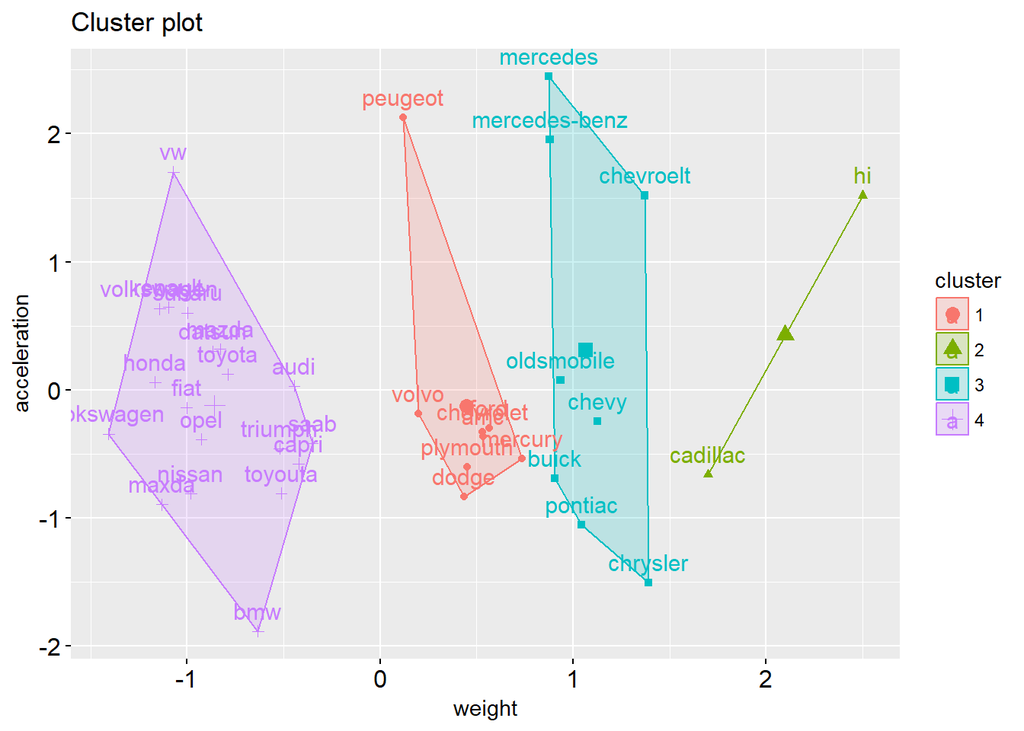

```r
km1 = kmeans(x = brand_set, centers = 4)
fviz_cluster(km1, data = brand_set)
```

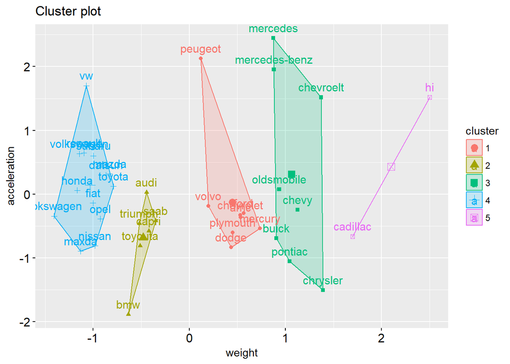

```r
km1 = kmeans(x = brand_set, centers = 5)
fviz_cluster(km1, data = brand_set)
```

Logically, 3 clusters seems the most rational approach.

Learn more about factoextra through the following article - Partitioning cluster analysis: Quick start guide - Unsupervised Machine Learning (http://www.sthda.com/english/wiki/partitioning-cluster-analysis-quick-start-guide-unsupervised-machine-learning)